NADAUD Edouard NESPOULOUS Guilhem NOBLANC Aymeric

```
                TD 2 - Auto-Regressive Integrated Moving Average
```

MON TP COMMENCE LIGNE 193 EN EFFET LE DEBUT SONT DES COPIE COLLER D’INTERNET ET DE LA PAGE ARMA.SIM QUI CORRESPONDENT AUX REPONSE DEMANDE

J’avais fait ces copié collé car nousa vons bcp de gros projet et ne connaisant pas le temps de rendu j’avais peur de ne pas avoir le temps de tout faire. Ayant reglé ce probleme je laisse ces copié coller qui sont de bonne qualité et presentent de bonnes visualisation

2. En utilisant la fonction R arima.sim, simuler plusieurs processus ARp et MAq (p et q d’un faible ordre de grandeur, c’est-à-dire [0,9]). Rappeler la formule mathématique des processus à simuler et vérifier que le choix de p et q respecte les conditions de stationnarité.
- MA

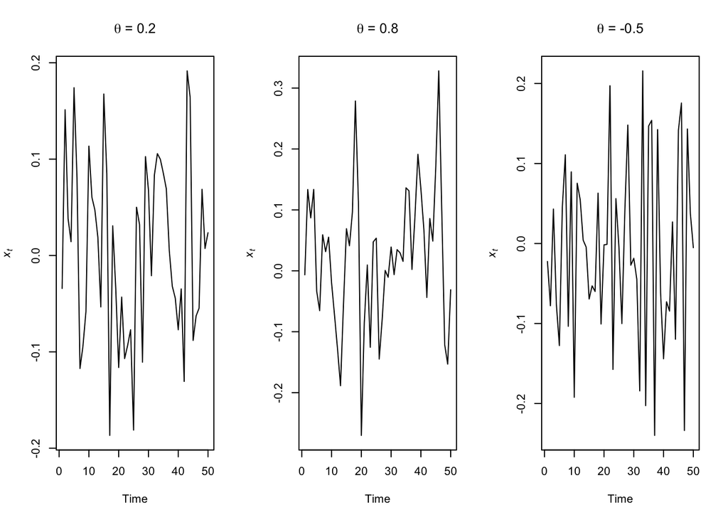

```r
set.seed(123)
## list description for MA(1) model with small coef
MA_sm <- list(order = c(0, 0, 1), ma = 0.2)
## list description for MA(1) model with large coef
MA_lg <- list(order = c(0, 0, 1), ma = 0.8)
## list description for MA(1) model with large coef
MA_neg <- list(order = c(0, 0, 1), ma = -0.5)
## simulate MA(1)
MA1_sm <- arima.sim(n = 50, model = MA_sm, sd = 0.1)
MA1_lg <- arima.sim(n = 50, model = MA_lg, sd = 0.1)
MA1_neg <- arima.sim(n = 50, model = MA_neg, sd = 0.1)
#with their associated plots.

## setup plot region
par(mfrow = c(1, 3))
## plot the ts
plot.ts(MA1_sm, ylab = expression(italic(x)[italic(t)]), main = expression(paste(theta,
    " = 0.2")))
plot.ts(MA1_lg, ylab = expression(italic(x)[italic(t)]), main = expression(paste(theta,
    " = 0.8")))
plot.ts(MA1_neg, ylab = expression(italic(x)[italic(t)]), main = expression(paste(theta,
    " = -0.5")))
```

- AR

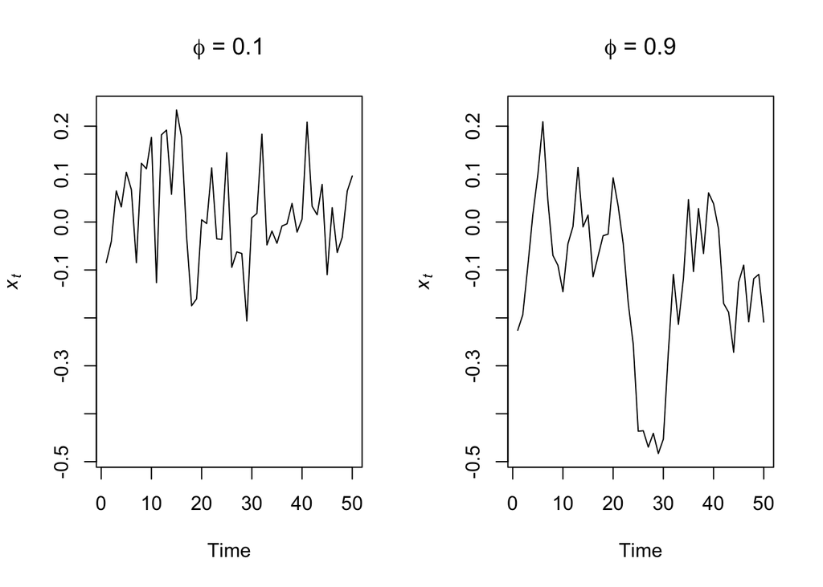

```r
set.seed(456)
## list description for AR(1) model with small coef
AR_sm <- list(order = c(1, 0, 0), ar = 0.1)
## list description for AR(1) model with large coef
AR_lg <- list(order = c(1, 0, 0), ar = 0.9)
## simulate AR(1)
AR1_sm <- arima.sim(n = 50, model = AR_sm, sd = 0.1)
AR1_lg <- arima.sim(n = 50, model = AR_lg, sd = 0.1)
#Now let’s plot the 2 simulated series.

## setup plot region
par(mfrow = c(1, 2))
## get y-limits for common plots
ylm <- c(min(AR1_sm, AR1_lg), max(AR1_sm, AR1_lg))
## plot the ts
plot.ts(AR1_sm, ylim = ylm, ylab = expression(italic(x)[italic(t)]),
    main = expression(paste(phi, " = 0.1")))
plot.ts(AR1_lg, ylim = ylm, ylab = expression(italic(x)[italic(t)]),
    main = expression(paste(phi, " = 0.9")))
```

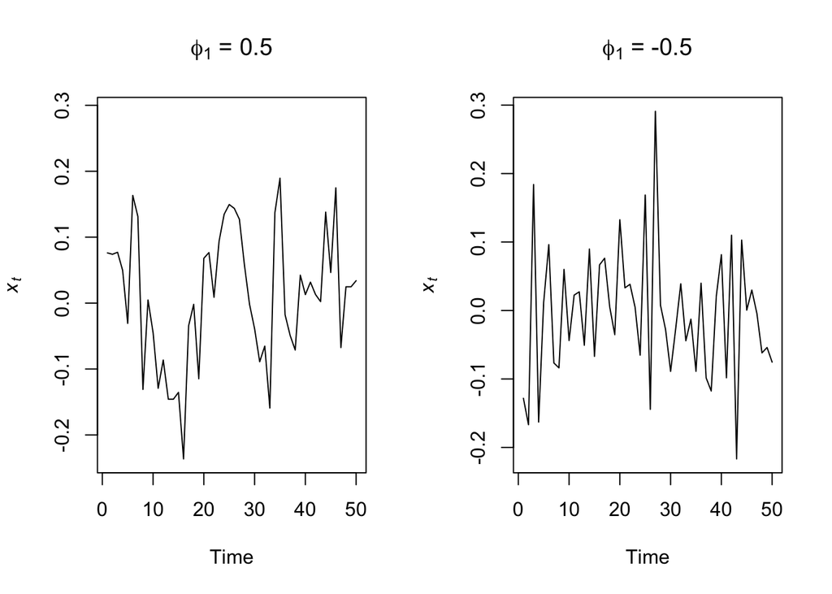

```r
set.seed(123)
## list description for AR(1) model with small coef
AR_pos <- list(order = c(1, 0, 0), ar = 0.5)
## list description for AR(1) model with large coef
AR_neg <- list(order = c(1, 0, 0), ar = -0.5)
## simulate AR(1)
AR1_pos <- arima.sim(n = 50, model = AR_pos, sd = 0.1)
AR1_neg <- arima.sim(n = 50, model = AR_neg, sd = 0.1)
#OK, let’s plot the 2 simulated series.

## setup plot region
par(mfrow = c(1, 2))
## get y-limits for common plots
ylm <- c(min(AR1_pos, AR1_neg), max(AR1_pos, AR1_neg))
## plot the ts
plot.ts(AR1_pos, ylim = ylm, ylab = expression(italic(x)[italic(t)]),
    main = expression(paste(phi[1], " = 0.5")))
plot.ts(AR1_neg, ylab = expression(italic(x)[italic(t)]), main = expression(paste(phi[1],
    " = -0.5")))
```

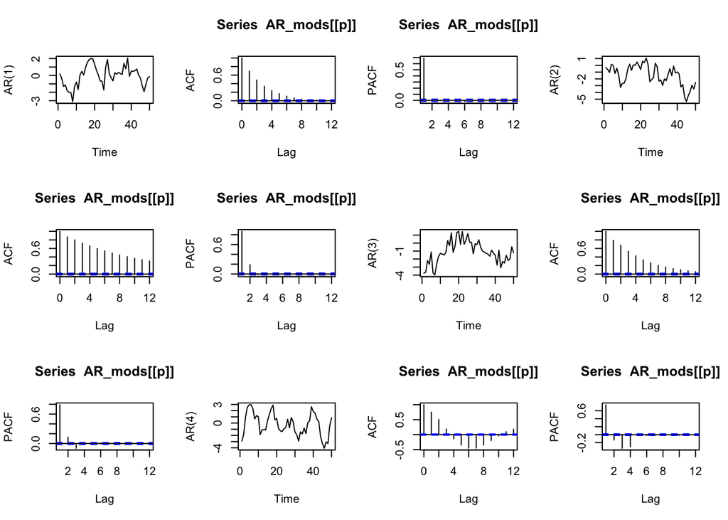

```r
set.seed(123)
## the 4 AR coefficients
AR_p_coef <- c(0.7, 0.2, -0.1, -0.3)
## empty list for storing models
AR_mods <- list()
## loop over orders of p
for (p in 1:4) {
    ## assume sd = 1, so not specified
    AR_mods[[p]] <- arima.sim(n = 10000, list(ar = AR_p_coef[1:p]))
}
#Now that we have our four AR( p ) models, lets look at plots of the time series, ACF’s, and PACF’s.

## set up plot region
par(mfrow = c(3, 4))
## loop over orders of p
for (p in 1:4) {
    plot.ts(AR_mods[[p]][1:50], ylab = paste("AR(", p, ")", sep = ""))
    acf(AR_mods[[p]], lag.max = 12)
    pacf(AR_mods[[p]], lag.max = 12, ylab = "PACF")
}
```

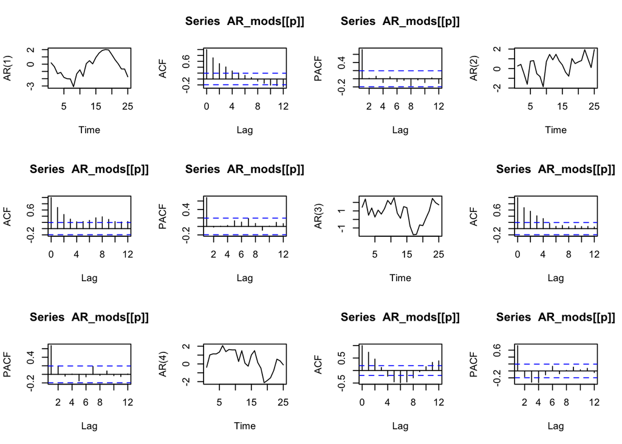

```r
set.seed(123)
#Coéfficient
AR_p_coef <- c(0.7, 0.2, -0.1, -0.3)

AR_mods <- list()
#ordreP
for (p in 1:4) {
    AR_mods[[p]] <- arima.sim(n = 100, list(ar = AR_p_coef[1:p]))
}

par(mfrow = c(3, 4))

for (p in 1:4) {
    plot.ts(AR_mods[[p]][1:25], ylab = paste("AR(", p, ")", sep = ""))
    acf(AR_mods[[p]], lag.max = 12)
    pacf(AR_mods[[p]], lag.max = 12, ylab = "PACF")}
```

3. Observer les auto-corrélations empiriques. Que constatez-vous?

Arma(1,2)

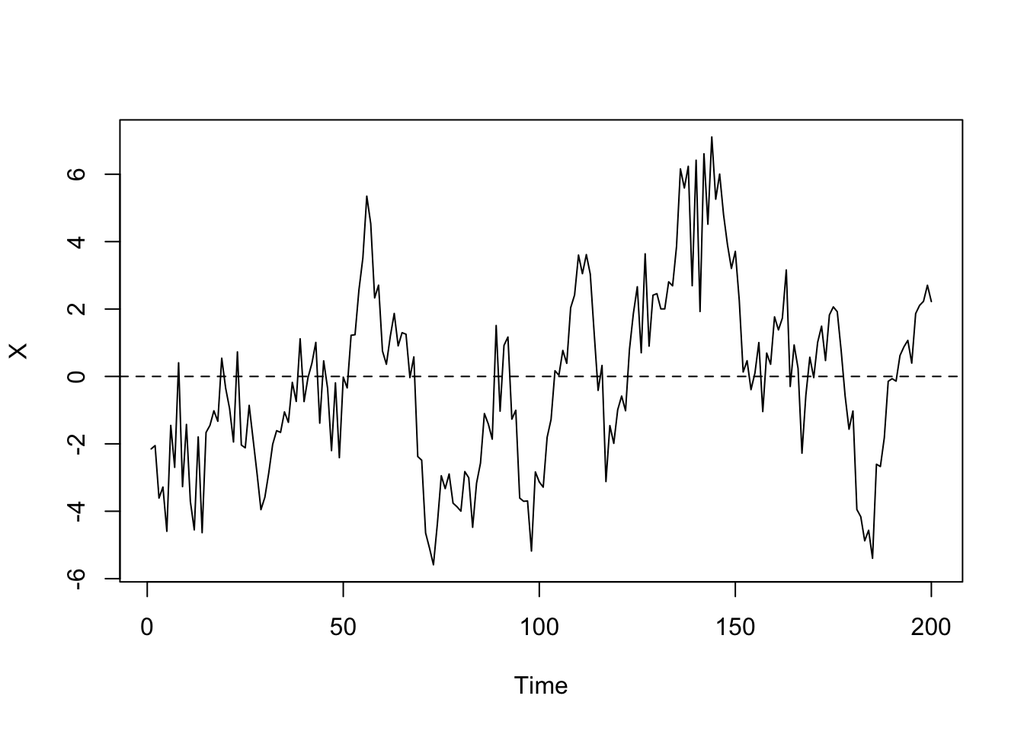

```r
X <- arima.sim(n=200,list(ar=c(0.8),ma=c(-0.3,0.6)),sd=sqrt(1.5))
plot(X)
abline(h=0,lty=2)
```

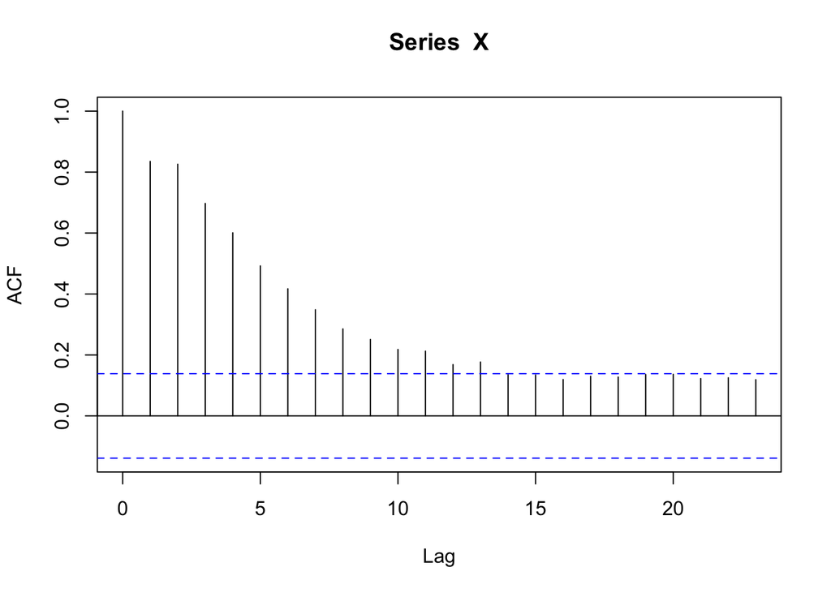

```r
acf(X,type=c("correlation"))
```

Arima(2,2)

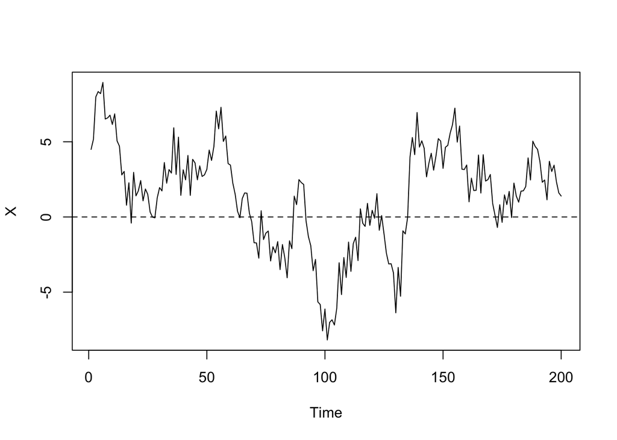

```r
X <- arima.sim(n=200,list(ar=c(0.8,0.1),ma=c(-0.3,0.6),order=c(2,0,2)),sd=sqrt(1.5))
plot(X)
abline(h=0,lty=2)
```

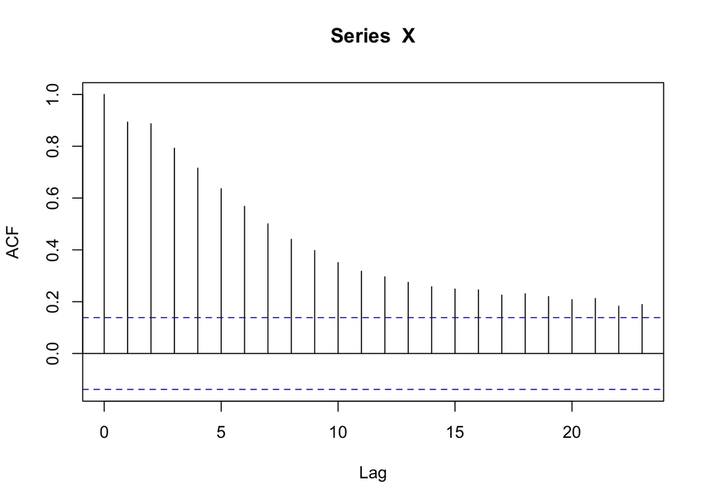

```r
acf(X,type=c("correlation"))
```

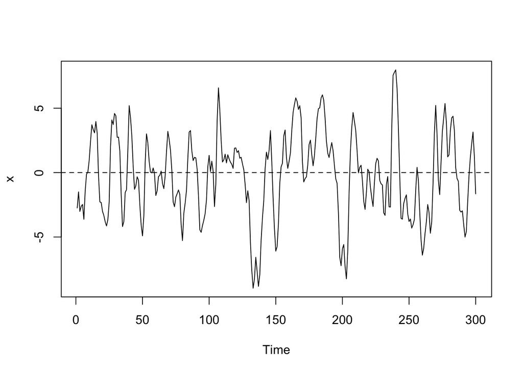

```r
x=arima.sim(model=list(ar=c(1,-0.25),ma=1),300,rand.gen=rnorm)
plot(x)
abline(h=0,lty=2)
```

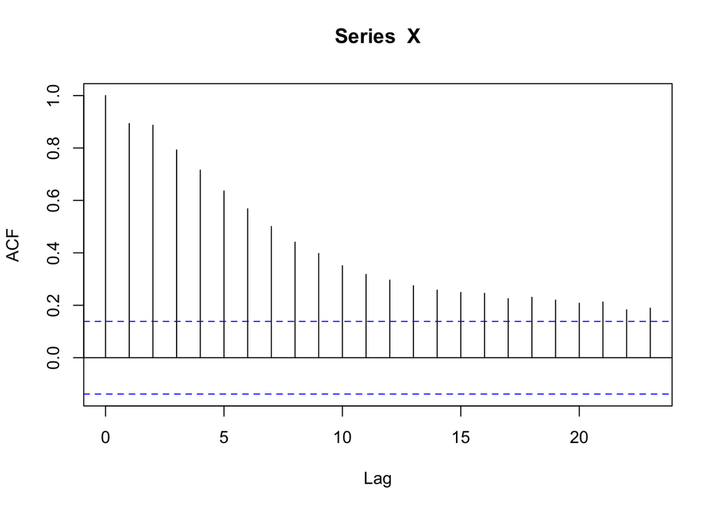

```r
acf(X,type=c("correlation"))
```

Partie I : Simulation de processus ARMA

1. Donner la définition d’un processus ARMAp, q. Quelles sont les conditions sur les coefficients pour que ce processus soit stationnaire?

-Processus stationnaire  sa moyenne E[Xt] ne dépend pas de t (constante),  pour tout h ∈ Z, cov(Xt,Xt−h) ne dépend pas de t (uniquement de h). -Processuss Arma stationaire -Pour trouver des coefficients qui correspondent a un processus stationnaire, il suffit de développer un polynôme dont les racines sont de module >1 Un processus stationnaire {Xt , t ∈ Z} obéit à un modèle ARMA(p,q) s’il vérifie une équation du type Xt = c+φ1Xt−1+φ2Xt−2+…+φpXt−p+Zt+θ1Zt−1+θ2Zt−2+…+θqZt−q,∀t ∈ Z, avec :  c ∈ R, (φ1,…,φp) ∈ Rp, (θ1,…,θq) ∈ Rq,  {Zt,t ∈ Z} un bruit blanc.

2. En utilisant la fonction R arima.sim, simuler plusieurs processus ARp et MAq (p et q d’un faible ordre de grandeur, c’est-à-dire [0,9]). Rappeler la formule mathématique des processus à simuler et vérifier que le choix de p et q respecte les conditions de stationnarité.